# 1 - Landscape and genetic data processing with `graph4lg`

UMR 6049 ThéMA - CNRS - Univ. Marie et Louis Pasteur, Besançon, France

Paul SAVARY

# Introduction

The rationale of the `graph4lg` package in R is to make the construction and analysis of genetic and landscape graphs easier for landscape genetic studies (hence the name `graph4lg`, meaning Graphs for Landscape Genetics). This package provides users with tools for:

- Landscape and genetic data processing
- Genetic graph construction and analysis
- Landscape graph construction and analysis
- Landscape and genetic graph comparisons

Each one of the vignettes associated with this package focuses on one of these points. This first vignette will focus on **landscape and genetic data processing**. It will describe the package functions allowing users to:

- Load genetic data and convert them in/from several formats
- Assess genetic diversity
- Compute distances: genetic distances, geographical distances, cost-distances
- Convert data objects in R to make analyses easier

## Data used in this vignette

The package already includes simulated data sets for genetic and spatial data, allowing users to discover its different functionalities. The first data set (`data_simul`) was simulated with CDPOP (Landguth and Cushman 2010) on a simulated landscape. It consists of 1500 individuals from 50 populations genotyped for 20 microsatellite loci. Individuals dispersed less when the cost-distance between populations was large. A landscape graph was created with Graphab Foltête et al. (2021) whose nodes were the 50 simulated populations and the links were weighted by cost-distance values between populations. The project created with Graphab was included into the package such that the landscape graphs and the cost-distance matrix can be easily imported into the R environment.

The second data set (`data_ex`) was simulated as the first one but included only 10 populations. It is used to generate quick examples.

# Genetic data loading and format conversions

The first type of functions from this package allows users to **process genetic data**. These functions load genetic data in an R environment and convert them when necessary.

In order to make the package user-friendly and compatible with genetic data commonly used in landscape genetics, the functions `genepop_to_genind`, `structure_to_genind`, `gstud_to_genind` and `loci_to_genind` allow users to convert genetic data from formats used respectively in the `gstudio` (Dyer 2009) and `pegas` (Paradis 2010) packages in R and in STRUCTURE (Pritchard et al. 2000) and GENEPOP (Raymond 1995) software into R objects with the class attribute `genind` from ADEGENET package (Jombart 2008). The **`genind` format** makes it possible to use time-efficient functions from the `adegenet` package (coded in C). This package was developed and is regularly maintained by Thibaut Jombart [(his website)](https://thibautjombart.netlify.app/). The `genind_to_genepop` function enables to convert `genind` object into text files in the `genepop` format in order to perform analyses with this commonly used R package and executable software. All these functions work with **microsatellite data (with 2 or 3-digits allele coding)**.

The package is **compatible with SNPs data** as long as they have been loaded into a `genind` object (ideally using the `vcfR` package with the `return.alleles = TRUE` option in the `vcfR::vcfR2genind()` function).

## GENEPOP to genind

The GENEPOP software (Raymond 1995) developed by M. Raymond and F. Rousset (Montpellier, France) can be used as an executable file, with or without graphical user interface, or as an R package [(GENEPOP git repository)](https://f-rousset.r-universe.dev/genepop). It is frequently used to compute F<sub>ST</sub> values and to test for Hardy-Weinberg equilibrium, linkage disequilibrium or genetic differentiation. Besides, when performing simulations with CDPOP (Landguth and Cushman 2010), individual genotypes can be saved as GENEPOP files at the end of the simulation.

The function `genepop_to_genind` loads a GENEPOP file (.txt extension) and converts it into a `genind` object. To use it, the path to the file, the total number and names of the loci and the population names must be indicated.

```r
data_genind <- genepop_to_genind(path = paste0(system.file('extdata',
                                                           package = 'graph4lg'),
                                               "/gpop_simul_10_g100_04_20.txt"),
                                 n.loci = 20, pop_names = as.character(1:10))
data_genind
```

```
#> /// GENIND OBJECT /////////
#>
#>  // 200 individuals; 20 loci; 124 alleles; size: 139.8 Kb
#>
#>  // Basic content
#>    @tab:  200 x 124 matrix of allele counts
#>    @loc.n.all: number of alleles per locus (range: 3-9)
#>    @loc.fac: locus factor for the 124 columns of @tab
#>    @all.names: list of allele names for each locus
#>    @ploidy: ploidy of each individual  (range: 2-2)
#>    @type:  codom
#>    @call: adegenet::df2genind(X = as.matrix(x[, attr(x, "locicol"), drop = FALSE]),
#>     sep = "/", pop = pop, ploidy = ploidy)
#>
#>  // Optional content
#>    @pop: population of each individual (group size range: 20-20)
```

## genind to GENEPOP

The `genind_to_genepop` function performs the reverse conversion, i.e., it converts a `genind` object into a GENEPOP file. This file is created and saved in the working directory defined earlier.

```r
genind_to_genepop(x = data_genind,
                  output = "data_gpop_test.txt")
```

This function can create, for example, a GENEPOP file to test for pairwise population genetic differentiation or to compute fixation indices with GENEPOP software.

## STRUCTURE to genind

The STRUCTURE software (Pritchard et al. 2000) is frequently used in population genetics and landscape genetics. It enables to create population clusters through a Bayesian approach aiming at minimising the deviation from Hardy-Weinberg equilibrium when merging populations together. The input files have a particular structure. The function `structure_to_genind` converts this type of file into a `genind` object.

To use the function, we need to indicate the path to the file, the names of the loci, the individual ID and the population names in the same order as in the original file.

```r
loci_names <- paste0("LOCI-", as.character(1:20))

ind_names <- as.character(1:200)
pop_names <- as.character(1:10)
data_paru <- structure_to_genind(path = paste0(system.file('extdata',
                                                           package = 'graph4lg'),
                                               "/data_ex_str.txt"),
                                 loci_names = loci_names,
                                 pop_names = pop_names,
                                 ind_names = ind_names)
data_paru
```

```
#> /// GENIND OBJECT /////////
#>
#>  // 200 individuals; 20 loci; 124 alleles; size: 139.5 Kb
#>
#>  // Basic content
#>    @tab:  200 x 124 matrix of allele counts
#>    @loc.n.all: number of alleles per locus (range: 3-9)
#>    @loc.fac: locus factor for the 124 columns of @tab
#>    @all.names: list of allele names for each locus
#>    @ploidy: ploidy of each individual  (range: 2-2)
#>    @type:  codom
#>    @call: adegenet::df2genind(X = as.matrix(x[, attr(x, "locicol"), drop = FALSE]),
#>     sep = "/", pop = pop, ploidy = ploidy)
#>
#>  // Optional content
#>    @pop: population of each individual (group size range: 20-20)
```

## gstud to genind

The `gstudio` and `popgraph` packages, developed by R. Dyer (Dyer 2009), use R `data.frames` as input data, with columns of class `locus`. These `data.frame` objects are `gstud` objects. Given these packages are often used to create genetic graphs, we created a function to convert them into the `genind` format.

A `gstud` object generally has the following structure (simulations with 10 populations as an example):

```r
print(head(data_ex_gstud))
```

```
#>    ID POP LOCUS-1 LOCUS-2 LOCUS-3 LOCUS-4 LOCUS-5 LOCUS-6 LOCUS-7 LOCUS-8
#> 23  1   1 116:130 104:104 123:123 103:103 124:124 106:113 113:117 101:101
#> 24  2   1 116:116 104:104 123:123 103:129 124:124 106:113 113:113 101:101
#> 25  3   1 130:130 104:104 123:123 103:103 124:124 106:113 113:113 101:101
#> 26  4   1 116:116 104:107 123:123 103:103 124:124 106:106 117:117 101:114
#> 27  5   1 116:130 104:107 123:123 103:103 124:124 106:106 113:117 101:114
#> 28  6   1 116:116 104:104 123:123 103:103 124:124 113:113 109:113 101:114
#>    LOCUS-9 LOCUS-10 LOCUS-11 LOCUS-12 LOCUS-13 LOCUS-14 LOCUS-15 LOCUS-16
#> 23 102:126  114:114  123:123  104:120  105:105  103:122  106:129  115:115
#> 24 126:126  114:118  123:123  120:120  104:105  103:103  116:116  102:115
#> 25 102:126  118:118  109:123  120:120  104:104  103:103  116:129  102:102
#> 26 102:126  118:118  123:123  104:120  105:105  103:103  116:129  115:115
#> 27 102:106  114:114  123:123  104:120  105:105  103:122  116:129  102:115
#> 28 124:126  114:114  123:123  104:104  105:105  103:122  106:106  102:102
#>    LOCUS-17 LOCUS-18 LOCUS-19 LOCUS-20
#> 23  103:103  122:122  129:129  109:130
#> 24  103:103  122:122  109:129  109:130
#> 25  103:103  122:122  109:122  109:109
#> 26  103:103  122:122  122:129  109:130
#> 27  103:103  122:122  129:129  109:130
#> 28  103:103  122:122  122:129  117:120
```

To convert it with the function `gstud_to_genind`, we indicate the name of the `data.frame` and of the columns containing population names and individual names:

```r
gstud_to_genind(x = data_ex_gstud, pop_col = "POP",
                ind_col = "ID")
```

```
#> Individuals in 'x' were not ordered, they have
#>             been ordered by populations and populations ordered in alphabetic
#>             order for the conversion.
#> /// GENIND OBJECT /////////
#>
#>  // 200 individuals; 20 loci; 124 alleles; size: 139.8 Kb
#>
#>  // Basic content
#>    @tab:  200 x 124 matrix of allele counts
#>    @loc.n.all: number of alleles per locus (range: 3-9)
#>    @loc.fac: locus factor for the 124 columns of @tab
#>    @all.names: list of allele names for each locus
#>    @ploidy: ploidy of each individual  (range: 2-2)
#>    @type:  codom
#>    @call: adegenet::df2genind(X = as.matrix(x[, attr(x, "locicol"), drop = FALSE]),
#>     sep = "/", pop = pop, ploidy = ploidy)
#>
#>  // Optional content
#>    @pop: population of each individual (group size range: 20-20)
```

# Genetic diversity assessment

Once a genetic dataset has been loaded in the R environment, the function `pop_gen_index` computes some **genetic diversity indices at the population level**.

```r
gen_div <- pop_gen_index(data_ex_genind)
print(head(gen_div))
```

```
#>    ID Nb_ind    A     Ho        He
#> 1   1     20 2.40 0.4000 0.3833750
#> 10 10     20 2.85 0.4850 0.4636250
#> 2   2     20 2.90 0.4250 0.4434375
#> 3   3     20 2.90 0.4700 0.4090625
#> 4   4     20 2.95 0.4675 0.4261250
#> 5   5     20 3.00 0.3925 0.4415625
```

# Distance calculations

In landscape genetics, apart from local population or landscape properties at the sampling site level, particular attention is given to **between population/habitat patch distances**. The package includes three functions to **compute both genetic and landscape distances**.

## Genetic distances

From a `genind` object, the `mat_gen_dist` function calculates several types of **between population genetic distances**:

- F<sub>ST</sub> (Weir and Cockerham 1984) or linearised F<sub>ST</sub> (Rousset 1997) (options ‘`dist=FST`’ and ‘`dist=FST_lin`’).
- G’<sub>ST</sub> (Hedrick 2005) (option ‘`dist=GST`’) (graph4lg <= 1.6.0).
- D<sub>Jost</sub> (Jost 2008) (option ‘`dist=D`’) (graph4lg <= 1.6.0).
- D<sub>PS</sub> (1 - proportion of shared alleles) Murphy et al. (2015) (option ‘`dist=DPS`’).
- Euclidean genetic distance (Excoffier et al. 1992) (option ‘`dist=basic`’).
- Euclidean genetic distance with a weighting depending on allelic frequencies giving more weight to rare alleles (Fortuna et al. 2009) (option ‘`dist=weight`’).
- Euclidean genetic distance computed after a PCA of the matrix of allelic frequencies by population. The axes considered to compute the Euclidean distance are the non-collinear principal components (total number of alleles - number of loci) Shirk et al. (2017) (option ‘`dist=PCA`’).
- Euclidean genetic distance computed in the same way as with the function `popgraph` from `popgraph` package, i.e. after a PCA and two SVD, among other computation steps (option ‘`dist=PG`’). This distance differs from the conditional genetic distance (cGD) computed from a population graph by summing genetic distances along shortest paths.

To do these calculations with the function `mat_gen_dist`, we just have to indicate the name of the `genind` object which includes the genetic data of the individuals as well as the populations to which each of them belongs. The other argument of the function is the type of genetic distance to compute. Here are two examples:

```r
mat_dps <- mat_gen_dist(x = data_genind, dist = "DPS")
```

```r
mat_dps[1:5, 1:5]
```

[output not shown]

```r
mat_pg <- mat_gen_dist(x = data_genind, dist = "PG")
```

```r
mat_pg[1:5, 1:5]
```

[output not shown]

## Geographical distances

The package also calculates **Euclidean geographical distances** between populations with the function `mat_geo_dist`. It takes as arguments:

- `data`: A `data.frame` with 3 columns corresponding to point ID, longitude (x) and latitude (y) whose column names are specified in other arguments below. It can also be an `sf` point spatial feature created in R or by importing a shapefile layer with the `sf` package.
- `ID`: population or point ID
- `x`: population or point longitude
- `y`: population or point latitude
- `crds_type`: “proj” or “polar”. Indicates whether coordinates are from a projected (“proj”) or a polar (“polar”) coordinate reference system.
- `gc_formula`: if coordinates are polar, then it specifies the formula to use. By default, the Vicenty formula is used.

When geographical coordinates are given in a **projected coordinate reference system (metric)**, Pythagoras’s theorem is used to compute the distances. Conversely, when they are given in a **polar CRS (degrees)**, Great Circle distances are computed. A warning message is displayed in every case.

Example with the 50 point projected coordinates included in the `pts_pop_simul` data set:

```r
print(head(pts_pop_simul))
```

```
#>   ID     x     y
#> 0  1 25650 54150
#> 1  2 22550 53650
#> 2  3  7250 51750
#> 3  4 32350 50550
#> 4  5 27350 49650
#> 5  6 15950 49550
```

```r
mat_geo <- mat_geo_dist(data = pts_pop_simul,
                        ID = "ID", x = "x", y = "y",
                        crds_type = "proj")
```

```
#> Coordinates were treated as projected coordinates. Check whether
#>               it is the case.
```

```r
mat_geo[1:5, 1:5]
```

```
#>           1         2        3         4         5
#> 1     0.000  3140.064 18555.86  7605.919  4810.405
#> 2  3140.064     0.000 15417.52 10278.619  6248.200
#> 3 18555.862 15417.522     0.00 25128.669 20209.404
#> 4  7605.919 10278.619 25128.67     0.000  5080.354
#> 5  4810.405  6248.200 20209.40  5080.354     0.000
```

Examples with 4 city **polar coordinates**:

```r
city_us <- data.frame(name = c("New York City", "Chicago",
                               "Los Angeles", "Atlanta"),
                   lat  = c(40.75170,  41.87440,
                            34.05420,  33.75280),
                   lon  = c(-73.99420, -87.63940,
                            -118.24100, -84.39360))

mat_geo_us <- mat_geo_dist(data = city_us,
                           ID = "name", x = "lon", y = "lat",
                           crds_type = "polar")
```

```
#> Coordinates were treated as polar coordinates. Check whether
#>               it is the case.
```

```r
head(mat_geo_us)
```

```
#>                  Atlanta    Chicago Los Angeles New York City
#> Atlanta              0.0   367050.9    16225865       1168203
#> Chicago         367050.9        0.0    16590655       1523685
#> Los Angeles   16225865.1 16590655.5           0      15072934
#> New York City  1168203.4  1523684.7    15072934             0
```

## Cost-distances

Because straight line Euclidean distances cannot accurately reflect how species move in landscapes, methods have been developed to better represent how they move by incorporating information about the resistance of landscape features to their movements. Among them, the computation of **least-cost paths** and of their **cumulated cost-distances along these paths** is a very popular approach.

The function `mat_cost_dist` makes possible the computation of **cost-distances between a set of points on a raster with discrete cell values** corresponding to land use types. Each land use type is given a cost reflecting its resistance to movement. A high value means that the cell is difficult to cross for an individual.

The `raster` input can be either:

- the path (`character string`) to a raster file in format .tif or .asc,
- a `SpatRaster` object already loaded in R environment with package `terra`.

The point (`pts`) input can be either:

- the path (`character string`) to a .csv file,
- a `data.frame` already loaded in R environment
- an `sf` point spatial feature created in R or by importing a shapefile layer with the `sf` package.

In all cases, this object must have three data columns indicating the point ID, x (longitude) and y (latitude) in a projected coordinate reference system.

To do the computation, we need to create a `data.frame` with two columns (`code` and `cost`) specifying the cost associated with every raster cell value.

By default, the computation is performed with `costDistance` function from `gdistance` package (`method = "gdistance"`). For example :

```r
x <- terra::rast(ncols = 10, nrows = 10,
                 xmin = 0, xmax = 100,
                 ymin = 0, ymax = 100)
terra::values(x) <- sample(c(1,2,3,4), size = 100, replace = TRUE)
pts <- data.frame(ID = 1:4,
                  x = c(10, 90, 10, 90),
                  y = c(90, 10, 90, 10))
cost <- data.frame(code = 1:4,
                   cost = c(1, 10, 100, 1000))
mat_cd <- mat_cost_dist(raster = x,
              pts = pts, cost = cost,
              method = "gdistance")
head(mat_cd)
```

```
#>          1        2        3        4
#> 1   0.0000 184.8492   0.0000 184.8492
#> 2 184.8492   0.0000 184.8492   0.0000
#> 3   0.0000 184.8492   0.0000 184.8492
#> 4 184.8492   0.0000 184.8492   0.0000
```

`gdistance` cannot perform the computation anymore when the raster size and the number of points increase. Using another coding language than R is a way to overcome this limitation. That is why the function `mat_cost_dist` includes **another method for computing cost distances**. It relies upon the .jar file `costdist-0.5.jar` (Java language), developed by Gilles Vuidel (UMR TheMA, Besancon, France). It is automatically downloaded by the user at the first use of the function `mat_cost_dist` with the argument `method = "java"`, provided Java is installed in the user’s machine. This program makes possible the **parallelisation of the computation**. The argument `parallel.java` takes values between 1 and the number of cores in the user’s machine - 1, thereby setting the number of cores used for the computation.

For example, when using `method="java"`, the command should be:

```r
mat_cost_dist(raster = x,
              pts = pts, cost = cost,
              method = "java",
              parallel.java = 2)
```

When `method="java"`, least cost paths progress in 8 directions from one cell, whereas it can be controlled when `method = "gdistance"` with the argument `direction=4` (or 8 or 16).

**When choosing which method?** Using `method="java"` becomes more and more interesting as the raster size and the number of points increase. In the previous example (raster: 10 $\times$ 10 cells, 4 points), using `method="gdistance"` is the fastest option (0.67 s. vs 2.56 s.). With a raster of 100 $\times$ 100 cells and 4 points, both methods are equivalent (2 s.). With a raster of 1000 $\times$ 1000 cells and 4 points, `method="java"` is by far the fastest (120 s. vs 8 s.).

Besides, **depending on the input data types**, computation times can vary:

- When using `method="java"`, the best option is to provide a .asc raster file and a .csv point file.
- When using `method="gdistance"`, the best option is to provide a `RasterLayer` object in R and a `SpatialPointsDataFrame` object in R.

**N.B.:** the `method="gdistance"` option relies on the `RasterLayer` format of the `raster` package. This package is progressively replaced by `terra`, which offers more stable functions and has more stable dependencies. In the future, this option might not be continued if `gdistance` does not update their dependency.

# Processing tools

The functions presented in the last sections create objects in R, such as `data.frame` and `matrix`. The package includes functions to process these objects, ordering them, comparing them and converting them.

## Reorder a matrix

In landscape genetics, when comparing two matrices of distances between the same sets of elements (e.g., doing a Mantel test to assess isolation by distance patterns), the two matrices must be ordered in the same way. The function `reorder_mat` reorders a symmetric matrix according to a specified order of its row/column names.

For example, when computing a geographical distance from a `data.frame` in which the `ID` column contains integer values, the resulting distance matrix is ordered in the increasing order of these ID (1, 2, 3, …., 10). If the same IDs are character strings, the resulting distance matrix will be ordered in alphabetical order (“1”, “10”, “2”, “3”, …, “9”). In the following example, we illustrate how to reorder a matrix in such a case.

```r
mat_g1 <- mat_geo_dist(pts_pop_ex,
                       ID = "ID", x = "x", y = "y",
                       crds_type = "proj")
```

```
#> Coordinates were treated as projected coordinates. Check whether
#>               it is the case.
```

```r
head(mat_g1)
```

```
#>          1         2         3        4         5        6        7         8
#> 1     0.00 30050.125 21967.248 41694.12 26916.352 19313.21 37283.91 29098.797
#> 2 30050.12     0.000  8360.024 11800.42  6529.931 23825.41 19804.04 25766.063
#> 3 21967.25  8360.024     0.000 19746.39  5728.001 16843.99 20392.40 21332.135
#> 4 41694.12 11800.424 19746.392     0.00 15582.362 32572.99 20145.72 31270.753
#> 5 26916.35  6529.931  5728.001 15582.36     0.000 17629.80 15280.05 19293.781
#> 6 19313.21 23825.407 16843.990 32572.99 17629.804     0.00 20333.47  9790.812
#>          9       10
#> 1 33737.96 29230.81
#> 2 24485.91 30425.15
#> 3 22000.23 25242.03
#> 4 27789.39 36391.76
#> 5 18483.51 23900.84
#> 6 14827.34 10647.07
```

```r
row.names(mat_g1)
```

```
#>  [1] "1"  "2"  "3"  "4"  "5"  "6"  "7"  "8"  "9"  "10"
```

```r
# Reorder mat_g1
mat_g2 <- reorder_mat(mat_g1,
                      order = as.character(1:10)[order(as.character(1:10))])
head(mat_g2)
```

```
#>           1       10         2         3        4         5        6        7
#> 1      0.00 29230.81 30050.125 21967.248 41694.12 26916.352 19313.21 37283.91
#> 10 29230.81     0.00 30425.154 25242.028 36391.76 23900.837 10647.07 18775.78
#> 2  30050.12 30425.15     0.000  8360.024 11800.42  6529.931 23825.41 19804.04
#> 3  21967.25 25242.03  8360.024     0.000 19746.39  5728.001 16843.99 20392.40
#> 4  41694.12 36391.76 11800.424 19746.392     0.00 15582.362 32572.99 20145.72
#> 5  26916.35 23900.84  6529.931  5728.001 15582.36     0.000 17629.80 15280.05
#>            8        9
#> 1  29098.797 33737.96
#> 10  5147.815 10348.43
#> 2  25766.063 24485.91
#> 3  21332.135 22000.23
#> 4  31270.753 27789.39
#> 5  19293.781 18483.51
```

```r
row.names(mat_g2)
```

```
#>  [1] "1"  "10" "2"  "3"  "4"  "5"  "6"  "7"  "8"  "9"
```

## Convert Euclidean distances into cost distances

Cost-distances are expressed in cost units arbitrarily defined based on the cost values assigned to every land cover type when creating resistance surfaces. However, species dispersal distances are usually known as distances expressed in metric units. When we know that the probability that a species covers 10 km is 5 %, we can ask what is the equivalent of this distance in cost distance units according to the assumed cost value scenario. It can be useful in order to prune a landscape graph with a given distance threshold or simply to get an idea of the order of magnitude of cost-distance values.

For that purpose, a **regression** of the **between population cost-distance** values against the corresponding **geographical distances** can be performed. It estimates the relationship between both types of distance. Then, the resulting parameter estimates enable to convert a geographical distance into its cost-distance equivalent according to the cost scenario.

The function `convert_cd` performs the linear regression or log-log linear regression between the geographical distance matrix and the cost-distance matrix, in the same way as Tournant et al. (2013) and as performed by Graphab software.

Below, we estimate the relationship between geographical distance and cost-distance between the populations used to perform the gene-flow simulation. We convert 10 km into cost-distance units. The function also plots the relationship between these distances.

```
#> $`Converted values`
#>    10000
#> 1605.543
#>
#> $`Model parameters`
#> Intercept     Slope
#> -2.251216  1.045828
#>
#> $`Model multiple R-squared`
#> Multiple R-squared
#>          0.6870757
#>
#> $Plot
```

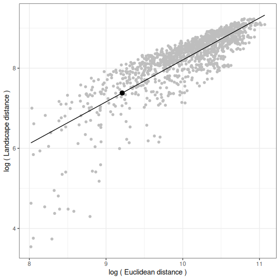

```r
mat_ld <- reorder_mat(mat_ld, order = row.names(mat_geo))

convert_res <- convert_cd(mat_euc = mat_geo, mat_ld = mat_ld,
                          to_convert = 10000, fig = TRUE,
                          method = "log-log", pts_col = "grey")
convert_res
```

A figure is returned as the fourth element of `convert_res`. The black dot represented on this figure refers to the 10 km value on the regression line characterising the relationship between cost-distance and geographical distance.

## From pairwise matrix to data frame

Distance values can be stored in two main ways. First, they can be stored in pairwise distance matrices. The distance between point $i$ and point $j$ is the value at the $i_{th}$ row and the $j_{th}$ column, and also at the $j_{th}$ row and the $i_{th}$ column. Such a matrix is the required input of analyses such as Mantel tests and can be used to create graphs when considered as an adjacency matrix.

However, it is quite an *heavy* object and these values can be stored in smaller objects called edge lists, which are basically tables with three columns: from, to, distance.

The function `pw_mat_to_df` converts a pairwise `matrix` into an edge list stored in a `data.frame` object.

```r
df_dist <- pw_mat_to_df(pw_mat = mat_geo)
print(head(df_dist))
```

```
#>     id_1 id_2 id_link     value
#> 1_2    1    2     1_2  3140.064
#> 1_3    1    3     1_3 18555.862
#> 2_3    2    3     2_3 15417.522
#> 1_4    1    4     1_4  7605.919
#> 2_4    2    4     2_4 10278.619
#> 3_4    3    4     3_4 25128.669
```

The resulting object `df_dist` is a `data.frame` with 4 columns: `id_1`, `id_2`, `id_link` and `value`.

## From data frame to pairwise matrix

Conversely, the function `df_to_pw_mat` converts an edge list stored in a `data.frame` object into a pairwise `matrix`.

```r
mat_dist <- df_to_pw_mat(data = df_dist,
                         from = "id_1", to = "id_2", value = "value")
mat_dist[1:5, 1:5]
```

```
#>           1         2        3         4         5
#> 1     0.000  3140.064 18555.86  7605.919  4810.405
#> 2  3140.064     0.000 15417.52 10278.619  6248.200
#> 3 18555.862 15417.522     0.00 25128.669 20209.404
#> 4  7605.919 10278.619 25128.67     0.000  5080.354
#> 5  4810.405  6248.200 20209.40  5080.354     0.000
```

# Conclusion

In the next vignette, we present **how to construct and analyse genetic graphs with `graph4lg`.**

# References

Bowcock, Anne M, A Ruiz-Linares, James Tomfohrde, Eric Minch, Judith R Kidd, and L Luca Cavalli-Sforza. 1994. “High Resolution of Human Evolutionary Trees with Polymorphic Microsatellites.” *Nature* 368 (6470): 455–57.

Dyer, Rodney J. 2009. “GeneticStudio: A Suite of Programs for Spatial Analysis of Genetic-Marker Data.” *Molecular Ecology Resources* 9 (1): 110–13.

Excoffier, Laurent, Peter E Smouse, and Joseph M Quattro. 1992. “Analysis of Molecular Variance Inferred from Metric Distances Among DNA Haplotypes: Application to Human Mitochondrial DNA Restriction Data.” *Genetics* 131 (2): 479–91.

Foltête, Jean-Christophe, Céline Clauzel, and Gilles Vuidel. 2012. “A Software Tool Dedicated to the Modelling of Landscape Networks.” *Environmental Modelling & Software* 38: 316–27.

Foltête, Jean-Christophe, Gilles Vuidel, Paul Savary, et al. 2021. “Graphab: An Application for Modeling and Managing Ecological Habitat Networks.” *Software Impacts* 8: 100065. https://doi.org/10.1016/j.simpa.2021.100065.

Fortuna, Miguel A, Rafael G Albaladejo, Laura Fernández, Abelardo Aparicio, and Jordi Bascompte. 2009. “Networks of Spatial Genetic Variation Across Species.” *Proceedings of the National Academy of Sciences* 106 (45): 19044–49.

Hedrick, Philip W. 2005. “A Standardized Genetic Differentiation Measure.” *Evolution* 59 (8): 1633–38.

Jombart, Thibaut. 2008. “Adegenet: A r Package for the Multivariate Analysis of Genetic Markers.” *Bioinformatics* 24 (11): 1403–5.

Jost, Lou. 2008. “GST and Its Relatives Do Not Measure Differentiation.” *Molecular Ecology* 17 (18): 4015–26.

Landguth, Erin L, and SA Cushman. 2010. “CDPOP: A Spatially Explicit Cost Distance Population Genetics Program.” *Molecular Ecology Resources* 10 (1): 156–61.

Murphy, Melanie, Rodney Dyer, and Samuel A. Cushman. 2015. “Graph Theory and Network Models in Landscape Genetics.” In *Landscape Genetics: Concepts, Methods, Applications*, 1st ed., edited by Niko Balkenhol, Samuel Cushman, Andrew Storfer, and Lisette Waits. John Wiley & Sons.

Paradis, Emmanuel. 2010. “Pegas: An r Package for Population Genetics with an Integrated–Modular Approach.” *Bioinformatics* 26 (3): 419–20.

Paschou, Peristera, Petros Drineas, Evangelia Yannaki, et al. 2014. “Maritime Route of Colonization of Europe.” *Proceedings of the National Academy of Sciences*.

Pritchard, Jonathan K, Matthew Stephens, and Peter Donnelly. 2000. “Inference of Population Structure Using Multilocus Genotype Data.” *Genetics* 155 (2): 945–59.

Raymond, Michel. 1995. “GENEPOP: Population Genetics Software for Exact Tests and Ecumenism. Vers. 1.2.” *Journal of Heredity* 86: 248–49.

Rousset, François. 1997. “Genetic Differentiation and Estimation of Gene Flow from f-Statistics Under Isolation by Distance.” *Genetics* 145 (4): 1219–28.

Shirk, AJ, EL Landguth, and SA Cushman. 2017. “A Comparison of Indiviudal-Based Genetic Distance Metrics for Landscape Genetics.” *Molecular Ecology* 17 (6).

Tournant, Pierline, Eve Afonso, Sébastien Roué, Patrick Giraudoux, and Jean-Christophe Foltête. 2013. “Evaluating the Effect of Habitat Connectivity on the Distribution of Lesser Horseshoe Bat Maternity Roosts Using Landscape Graphs.” *Biological Conservation* 164: 39–49.

Weir, Bruce S, and C Clark Cockerham. 1984. “Estimating f-Statistics for the Analysis of Population Structure.” *Evolution* 38 (6): 1358–70.